# PG2

# Casos adicionales

Para poder determinar si la variable aleatoria edad puede ser modelada por un modelo normal se tuvo el criterio de observación de su gráfico y de la simulitud o cercanía de sus valores de la media, la mediana y la moda.

```
##            Edad del seguidor (año)
## Media      18.46
## Mediana    19
## Moda       19
```

Los valores que son más frecuentes o que tienen más probabilidad de aparecer están alrededor de la media.

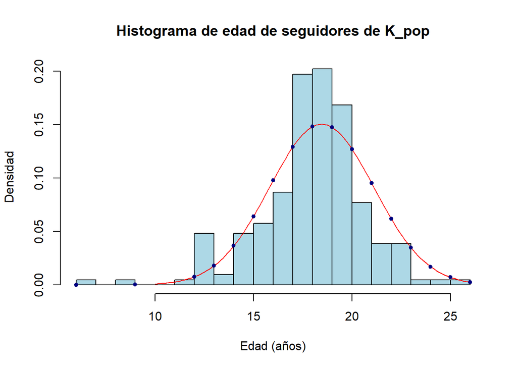

- Apreciamos que la mayoría de los datos están concentrados entre 17 y 20.
- Los valores de la media, moda y mediana son parecidos, por lo cual la variable se distribuye de manera casi simétrica.

Finalmente, las variables que al parecer se aproximan a un modelo exponencial son los años de seguimiento al género Kpop (Seguimiento) y la y el tiempo dedicado por los seguidores de este género para informarse respecto a a todo lo referente de sus Idols (Tiempo_Dedicado), para poder corroborar una modelación adecuada compararemos el parámetro lambda con el valor máximo de la función de densidad

```
## $`Consumo mensual.Lambda`
## [1] 0.1812
##
## $Inversión.Lambda
## [1] 0.4622
```

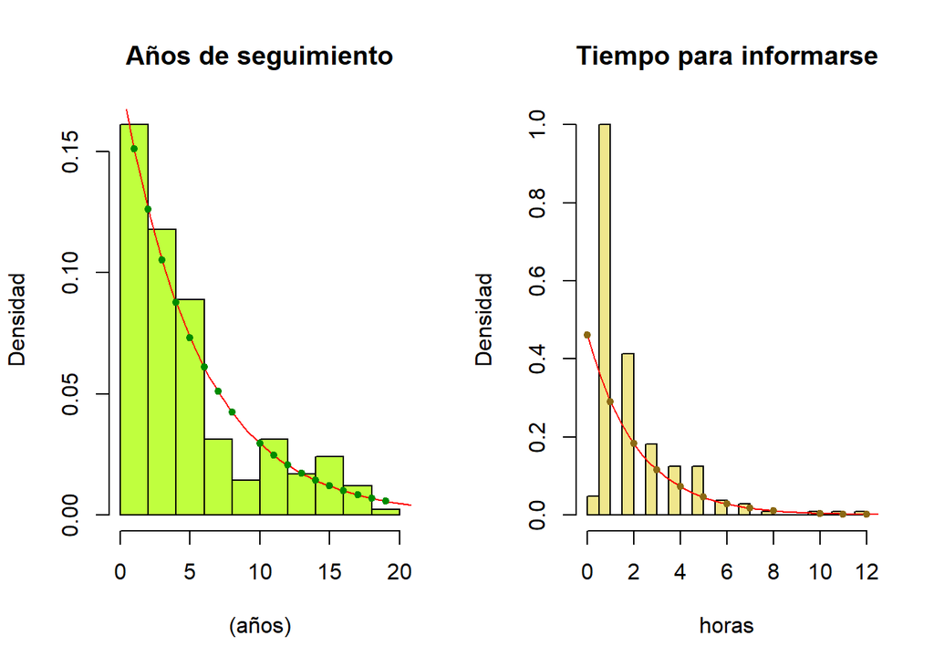

### Observaciones de la variable “tiempo para informarse sobre el género”

- Al hallar el lambda del histograma muestra se obtuvo un alto nivel de parecido a una distribución exponencial con un lambda igual a 0.4622.
- Una discordancia con el modelo exponencial es que una variable exponencial tiende al infinito, pero en este el tiempo para informarse al día sobre el género es finito (nadie puede seguir al género por infinitos años)

## Bibliografía

El modelo económico del K-pop, la industria cultural que se toma al mundo. (s/f). Diario La República. Recuperado el 30 de septiembre de 2022, de (https://www.larepublica.co/ocio/el-modelo-economico-detras-del-k-pop-2828863)

El Kpop, un fenómeno impactante en las redes sociales de Perú. (s/f). Com.pe. Recuperado el 30 de septiembre de 2022, de (https://www.businessempresarial.com.pe/el-kpop-un-fenomeno-impactante-en-las-redes-sociales-de-peru/)